# STATS 769 Lab 02

The purpose of this lab is to get experience downoading datasets from APIs and working with structured data formats.

For this lab you can use any machine that has R, all necessary packages and `curl`. It is recommended to run it on the VMs.

You should NOT use ‘tidyverse’ packages in your R code. Those packages are not (yet) installed on the virtual machines, so your code will not run on the virtual machines if you use the ‘tidyverse’ (and that will be bad when the marker runs your code on the virtual machines).

## The Data Set

[OpenMeteo.com](https://open-meteo.com/) provides an API for access to both historical weather data as well as weather predictions. The values are based on an aggregation of data from worldwide weather stations and creating a world-wide grid of estimates (on land at 0.25 latitude/longitude interval) called [ERA5](https://cds.climate.copernicus.eu/cdsapp#!/dataset/reanalysis-era5-single-levels).

### Import

You goal is to download daily low/high temperature for Auckland between 1 January 1980 and 30 June 2022. Visit the historical API decription page: https://open-meteo.com/en/docs/historical-weather-api and construct a URL that includes the desired data. You will need to set the parameters `latitude`, `longitude`, `daily`, `timezone`, `start_date` and `end_date`. You should use the time zone `"Pacific/Auckland"`.

1. Use the `curl` command in unix to download the result into the file `akl.json`. (Hint: look at the resulting file to ensure correctness of your request; the `&` character has a special meaning in the shell and must be escaped).
2. Read the result into an R object `jd`.

   It should look something like this:

   ```r
      str(jd)
      List of 7
       $ latitude          : num -36.8
       $ longitude         : num 175
       $ generationtime_ms : num 62.3
       $ utc_offset_seconds: int 43200
       $ elevation         : num 44
       $ daily_units       :List of 3
        ..$ time              : chr "iso8601"
        ..$ temperature_2m_max: chr "°C"
        ..$ temperature_2m_min: chr "°C"
       $ daily             :List of 3
        ..$ time              : chr [1:15522] "1980-01-01" "1980-01-02" "1980-01-03" "1980-01-04" ...
        ..$ temperature_2m_max: num [1:15522] 19.6 19.9 18.9 20.7 21.4 20.1 20.6 21.2 20.7 21.3 ...
        ..$ temperature_2m_min: num [1:15522] 15.1 15.3 15.3 13.6 14.8 15.2 16.5 16.1 17.6 17.5 ...
   ```

### Clean

3. Create a data frame `d` with the columns `day`, `min` and `max` from the obejct `jd` such that it looks like this:

   ```r
      str(d)
      'data.frame': 15522 obs. of  3 variables:
       $ day: Date, format: "1980-01-01" "1980-01-02" ...
       $ min: num  15.1 15.3 15.3 13.6 14.8 15.2 16.5 16.1 17.6 17.5 ...
       $ max: num  19.6 19.9 18.9 20.7 21.4 20.1 20.6 21.2 20.7 21.3 ...
   ```

### Explore

4. Check if the data is complete. Verify the sanity of the data.

### Model

5. We want to focus on the evolution of yearly average temperatures over time. In order to do that, let us define a daily mean estimate by taking the average of the minimum and maximum each day. Then for each year compute the averge of those daily averages. It should look something like this:

   ```r
      str(avg)
      'data.frame': 43 obs. of  2 variables:
       $ year: int  1980 1981 1982 1983 1984 1985 1986 1987 1988 1989 ...
       $ avg : num  15.2 15.9 15.2 15.1 15.7 ...
   ```

   Use years 1980-2014 as training set and remaining data as a test set. Fit two models to the training data: a simple overall mean and a linear regression model with the year as a predictor variable. Print the models and compute RMSE for the test set. Plot all the data and predictions.

   Do you see a problem in the test set? Explain it (use R code to provide evidence for your hypothesis), propose a way to handle it, implement it using R and repeat the model validation. Comment on the suitability of the two models.

## Revisit

6. You have found a data source listing all notable cities in New Zealand in a table: `https://stat.auckland.ac.nz/~su/769/demo/nzcities.html`.

   Write R code that reads the `html` page into R and extracts the contained table into a data frame `cities` (Hint: use XPath to find the `<table>` elements). It should look something like this:

   ```
      'data.frame': 36 obs. of  9 variables:
       $ city             : chr  "Auckland" "Wellington" "Christchurch" "Manukau City" ...
       $ lat              : num  -36.9 -41.3 -43.5 -37 -36.8 ...
       $ lng              : num  175 175 173 175 175 ...
       $ country          : chr  "New Zealand" "New Zealand" "New Zealand" "New Zealand" ...
       $ iso2             : chr  "NZ" "NZ" "NZ" "NZ" ...
       $ admin_name       : chr  "Auckland" "Wellington" "Canterbury" "Auckland" ...
       $ capital          : chr  "admin" "primary" "admin" "" ...
       $ population       : int  1470100 418500 377200 375600 208100 205605 169300 135000 106200 103400 ...
       $ population_proper: int  1470100 418500 377200 375600 208100 205605 169300 135000 106200 103400 ...
   ```

   Use the contained coordinates to fetch the maximum daily temperatures for the most populous 5 cities for the period from 2021-01-01 to 2021-12-31 from the Open Meteo API and plot the result. It should look something like this:

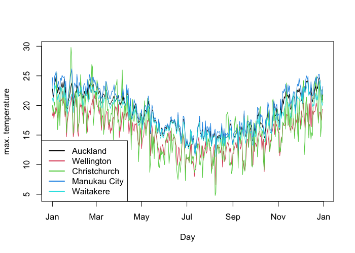

   Comment on the plot.

## Summary

12. Write a summary of your findings.

# The Report

Your submission should consist of an R Markdown document, submitted via Canvas. You should write your document so that it can be processed on a computer without any manual intervention. For example, do not include any calls to `setwd()` or `file.choose()`. You should write code that assumes that data files are in the current working directory or at a fixed location (`/course/data/...`) on the VMs. Also submit a processed version of your R Markdown document (an HTML document) in case we cannot process your document on the VM.

Your report should include:

- A brief description of the data.
- For each task, R code AND a brief text commentary.
- A summary of the entire report.

# Marking

Marks will be lost for:

- R Markdown file is missing.
- R Markdown file does not run.
- Processed file (HTML) is missing.
- Section of the report is missing.
- Unintelligible, or confusing, or irrelevant summary.
- Significantly poor R (or other) code.
- Overly verbose code, output, or commentary.